# World Happiness Analysis

### Poor became even poorer

This is how `diff.total` per country looks like, each point corresponds to a difference in score of a single country:

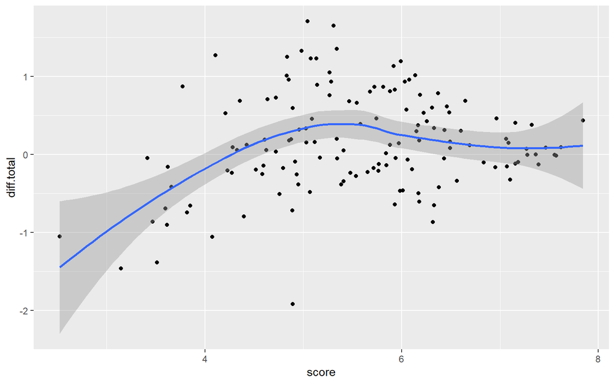

```r
diff21 %>% ggplot(aes(x=score, y=diff.total)) + geom_point() + geom_smooth()
```

It seems that the lower the happiness - the biggest the `diff`. particularly - the negative `diff`.

To examine this, we will look at two plots - boxplot for `diff.total`, and boxplot for `diff.abs`. The goal is to see both direction of the change and value of it.

```r
# divide scores into 3 groups - low, medium and high
scoreLevel = function (scores){
 sapply(scores, function(scores){
   if (scores < 4){
     return('low')
   }
   if(scores<6){
     return('medium')
   }
   return('high')
 })

}

diff21 = diff21 %>% mutate(score_level = scoreLevel(diff21$score)) %>%
        mutate(score_level = factor(score_level, levels = c('low', 'medium', 'high')))
```

#### diffreance

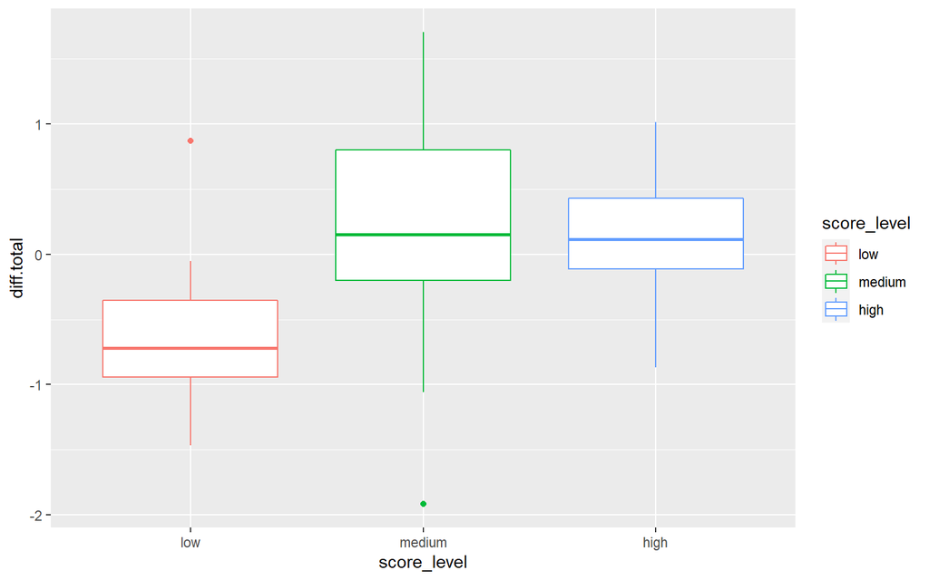

```r
# boxplot of dif.total
diff21 %>% ggplot(aes(x=score_level, y=diff.total, color=score_level)) + geom_boxplot()
```

```r
# means of each group
diff21 %>% group_by(score_level) %>% summarise(mean=mean(diff.total))
```

```
## # A tibble: 3 x 2
##   score_level   mean
##   <fct>        <dbl>
## 1 low         -0.627
## 2 medium       0.267
## 3 high         0.148
```

#### absolute diffreance

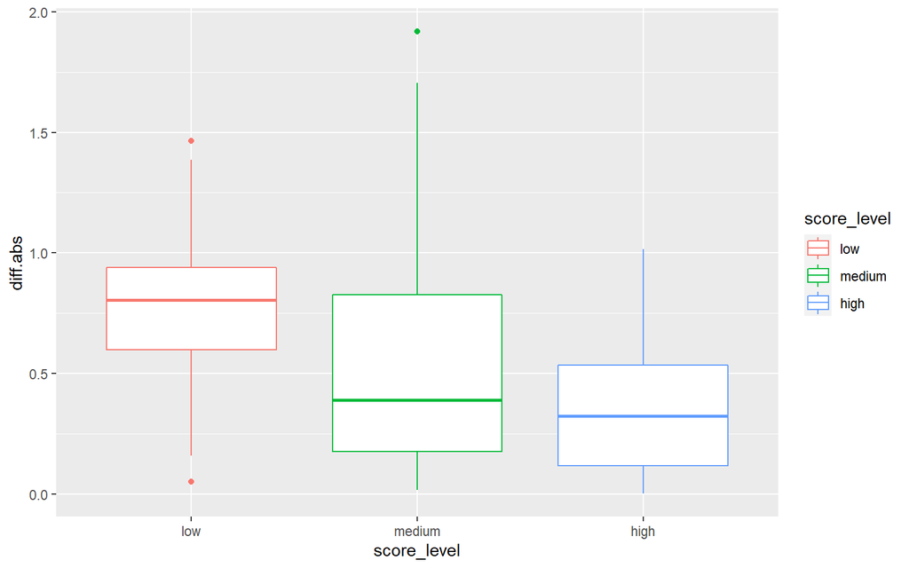

```r
# boxplot of dif.abs
diff21 %>% ggplot(aes(x=score_level, y=diff.abs, color=score_level)) + geom_boxplot()
```

### Results

First, it is clear both that the difference for low-happiness countries is negative, and that for medium and high, it is positive.

Second, the score of happier countries tend to change less.

# Conclusions

We hope you enjoyed our research. We have answered many questions, and invoked others.  
We have learned that happiness is very hard to measure. And is extremely subjective.  
We have also learned to never use “world happens report” data again, as it is not very tidy and poorly documented.

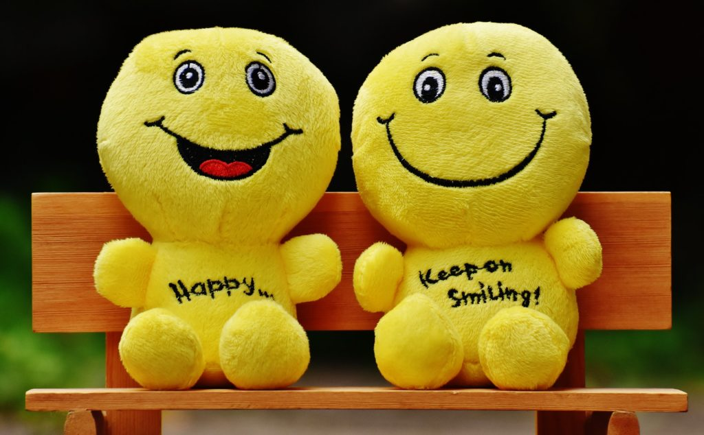